#### 01/2024

#### Máster de Ciencia de Datos de la UOC

# Mejoras en el dataset

## Índice

- Exploración de atributos adicionales
- Manipulación y consolidación
- Selección de atributos

## Exploración de atributos adicionales

```python
from pyspark.sql import SparkSession

# inicio sesion de spark
spark = SparkSession.builder.appName('Read Files').getOrCreate()
```

Se leen los archivos del anterior ciclo, los dataframes de usuarios y consumos están limpios, el de sesiones está la agregación ya preparada.

Se va a enriquecer el dataframe consolidado del primer ciclo con todos los atributos restantes de consumos que se pueden llegar a utilizar. Existe un atributo que define si un producto gratuito consumido es una ficha básica de una empresa o es un perfil promocional. Se visualiza la distribución de este dato en función si es o no un cliente.

```python
from pyspark.sql.functions import *
from pyspark.sql.types import *
from pyspark.sql.window import Window
import seaborn as sns
import matplotlib.pyplot as plt
import pandas as pd

usuarios = spark.read.parquet('/Archivos/usuariosPostLimpieza.parquet')

consumos = spark.read.parquet('/Archivos/consumosPostLimpieza.parquet')

consolidacion = spark.read.parquet("/Archivos/consolidacion.parquet")
```

Se añade la variable target a consumos para poder visualizarlo:

```python
consumos = consumos.join(usuarios.select("IDUSUARIO","IND_CLIENTE"), "IDUSUARIO", "left")
```

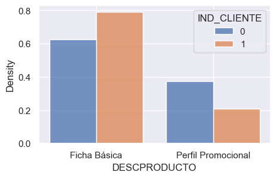

```python
plt.figure(figsize=(5,3))
sns.set(style='darkgrid')
sns.histplot(data=consumos.toPandas(), x="DESCPRODUCTO", stat="density", hue="IND_CLIENTE",
             common_norm=False, multiple="dodge", shrink = 0.8)
plt.show()
```

Como se puede observar, la distribución del tipo de producto es diferente si es un cliente o no lo es. Los usuarios que acaban comprando consumen un mayor número de fichas básicas que de perfiles promocionales. Si se recuerda, la oferta de los perfiles promocionales únicamente es durante el primer mes después de registrarse, además, únicamente se pueden consumir hasta cinco perfiles promocionales, mientras que se pueden consumir todas las fichas básicas que se quieran. Esta distribución puede estar diciendo que los usuarios que acabaran comprando, al estar interesados en los producos que oferta el ecommerce, consumen más productos de tipo ficha básica al explorar el site, mientras que los usuarios que no compran, al consumir menos productos, tienen un mayor porcentaje de perfiles promocionales consumidos.

Se va a hacer una pequeña agrupación a modo de analizar el número de consumos de perfiles promocionales dependiendo de si el usuario es un cliente o no, para explorar si es necesario ofertar 5 perfiles promocionales durante el mes de la oferta o realmente no se estan utilizando para los usuarios que acaban transformándose en clientes.

```python
consumosPromo = consumos.where("DESCPRODUCTO == 'Perfil Promocional' and IND_CLIENTE is not null")\
                .groupBy("IDUSUARIO","IND_CLIENTE").agg(count("IDCONSUMO").alias("numConsumos"))\
                .groupBy("IND_CLIENTE","numConsumos").agg(count("IDUSUARIO").alias("numUsuarios"))\
                .orderBy("IND_CLIENTE","numConsumos")
consumosPromo.toPandas()
```

|  | IND_CLIENTE | numConsumos | numUsuarios |
| --- | --- | --- | --- |
| 0 | 0 | 1 | 99504 |
| 1 | 0 | 2 | 8768 |
| 2 | 0 | 3 | 4748 |
| 3 | 0 | 4 | 3747 |
| 4 | 0 | 5 | 12433 |
| 5 | 1 | 1 | 1615 |
| 6 | 1 | 2 | 212 |
| 7 | 1 | 3 | 72 |
| 8 | 1 | 4 | 46 |
| 9 | 1 | 5 | 76 |

Se muestra la agregación en una visualización para mayor énfasis.

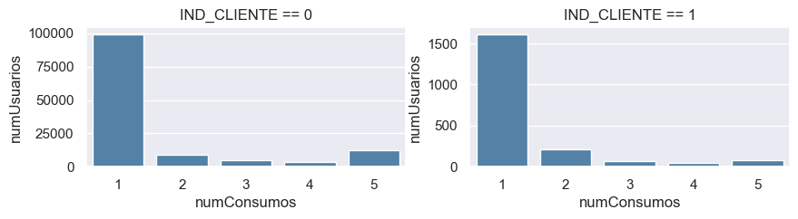

```python
fig, axs = plt.subplots(1,2,figsize=(10,2))
sns.set(style='darkgrid')
sns.barplot(data=consumosPromo.where("IND_CLIENTE == '0'").toPandas(), x="numConsumos", y="numUsuarios",
            color="steelblue", ax=axs[0]).set_title("IND_CLIENTE == 0")
sns.barplot(data=consumosPromo.where("IND_CLIENTE == '1'").toPandas(), x="numConsumos", y="numUsuarios",
            color="steelblue", ax=axs[1]).set_title("IND_CLIENTE == 1")
plt.show()
```

Como se puede observar en la tabla de los usuarios que han consumido algún perfil promocional y en las visualizaciones, se consume en su mayoría únicamente un producto de estas características en las dos poblaciones, aunque los clientes también pueden llegar a consumir dos productos, en comparación a los no clientes. Se encuentra que puede no ser necesario ofertar hasta 5 productos en un mes, ya que se encuentra que los que maximizan consumir todos los productos son los no clientes como se refleja en el gráfico de la izquierda. Este comportamiento puede reflejar a los usuarios que van creando cuentas con el único objetivo de consumir todo el contenido gratuito disponible, por no querer gastar dinero u otras razones. Este descubrimiento se podría enviar al departamento de márqueting del ecommerce para que lo tuvieran en cuenta. Por ejemplo, se podría reducir a 3 perfiles promocionales para desincentivar a los creadores de múltiples cuentas ya que sería más pesado para ellos por tener que crear más para obtener la misma cantidad de información.

Otro conjunto de atributos que no se utilizaron anteriormente es sobre información de la empresa consultada. De las variables disponibles, la descripción del sector y la provincia (o departamento como se denomina en Colombia) son los atributos relevantes, por lo que se va a hacer una exploración de las dos variables categóricas.

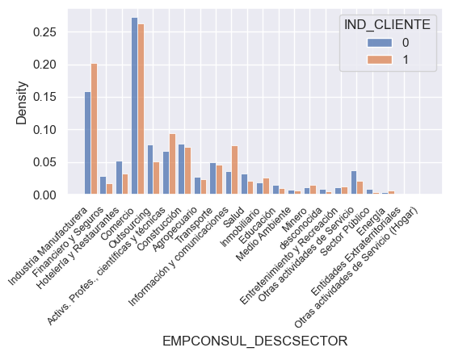

```python
plt.figure(figsize=(6,3))
sns.set(style='darkgrid')
sns.histplot(data=consumos.toPandas(), x="EMPCONSUL_DESCSECTOR", stat="density", hue="IND_CLIENTE",
             common_norm=False, multiple="dodge", shrink = 0.8)
plt.xticks(rotation=45, horizontalalignment="right",fontsize=9)
plt.show()
```

Se puede observar que hay un gran número de sectores posibles, donde el sector de la industria manufacturera y el comercio son los que engloban alrededor del 40% de las empresas consumidas tanto para la población de clientes como los otros usuarios. Se puede encontrar diferencias visibles en el gráfico entre una población u otra, como para la industria manufacturera, las actividades profesionales científicas y técnicas, y para el sector de la información y comunicaciones. Estas diferencias entre poblaciones podrían dar información relevante al modelo, mientras que otros sectores no serían destacables.

Si visualizamos por departamento:

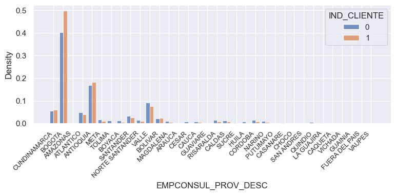

```python
plt.figure(figsize=(9,3))
sns.set(style='darkgrid')
sns.histplot(data=consumos.toPandas(), x="EMPCONSUL_PROV_DESC", stat="density", hue="IND_CLIENTE",
             common_norm=False, multiple="dodge", shrink = 0.8)
plt.xticks(rotation=45, horizontalalignment="right",fontsize=9)
plt.show()
```

Se comprueba que de los 33 departamentos, la capital Bogotá es la que recoge al 50% de los clientes, mientras que para los no clientes es de un 40%. La proporción entre departamentos está correlacionada con la población de los mismos, ya que el segundo departamento más grande en población es Antioquia, seguido del Valle del Cauca y Cundinamarca. Esta correlación es natural, ya que un mayor número de habitantes tendría que implicar un mayor número de empresas en la región. Lo más importante en estos datos será la diferencia entre poblaciones en cada departamento, por ejemplo, se podría llegar a la hipótesis de que, en la capital, al haber un mayor número de riqueza, más usuarios potenciales estudiarán empresas del entorno para invertir.

## Manipulación y consolidación

Debido a esta nueva exploración, se va a hacer la siguiente agregación de estas columnas. Como se tiene un dataframe con todos los consumos por usuarios y un único usuario puede consumir más de un tipo de producto de diferentes empresas que esten en distintos departamentos, se utilizará la moda de las tres nuevas variables. De esta forma para cada usuario se obtendrá la información más recurrente de cada variable. Otra posibilidad podría haber sido el obtener el número de consumos de perfil promocional y el de ficha básica por separado, pero como el perfil promocional sólo se puede consumir como máximo 5 veces, el valor de número de consumos totales sería muy similar a los de ficha básica, por lo que tiene más sentido tener el total y el valor modal del tipo, recogiendo la información de forma similar.

```python
consumosAgregacion = consumos.groupBy("IDUSUARIO")\
                             .agg(mode("EMPCONSUL_SECTOR").alias("sectorId"),
                                  mode("EMPCONSUL_PROV_DESC").alias("departamentoEmpr"),
                                  mode("DESCPRODUCTO").alias("tipoProducto"))
```

Se verifica un ejemplo:

```python
consumosAgregacion.where("IDUSUARIO == '8250281'").toPandas()
```

|  | IDUSUARIO | sectorId | departamentoEmpr | tipoProducto |
| --- | --- | --- | --- | --- |
| 0 | 8250281 | L | ANTIOQUIA | Ficha Básica |

```python
consumos.select("IDUSUARIO","DESCPRODUCTO","EMPCONSUL_SECTOR","EMPCONSUL_DESCSECTOR","EMPCONSUL_PROV_DESC")\
        .where("IDUSUARIO == '8250281'").toPandas()
```

|  | IDUSUARIO | DESCPRODUCTO | EMPCONSUL_SECTOR | EMPCONSUL_DESCSECTOR | EMPCONSUL_PROV_DESC |
| --- | --- | --- | --- | --- | --- |
| 0 | 8250281 | Ficha Básica | L | Inmobiliario | ANTIOQUIA |
| 1 | 8250281 | Ficha Básica | L | Inmobiliario | ANTIOQUIA |
| 2 | 8250281 | Perfil Promocional | I | Hotelería y Restaurantes | BOGOTA |

Una vez se tiene la nueva agregación de consumos, se van a enriquecer los datos ya que para tranformar las dos nuevas variables categóricas a columnas binarias con one-hot-encoding, se podría llegar a tener problemas por aumentar tanto la dimensionalidad (curse of dimensionality en inglés).

Con la variable del sector de la empresa se podría haber transformado al número de empresas de cada sector o el PIB que aportan, convirtiendo una variable categórica a numérica, pero no se han encontrado datos de todos los sectores, por lo que esta variable se transformará directamente a columnas binarias con one-hot-encoding.

La variable del departamento de la empresa sí que es más abarcable, por lo que se ha transformado a una variable numérica con el producto interior bruto (PIB) de cada uno. Se ha utilizado el PIB en vez de la población ya que un mayor número de habitantes no implica un mayor número de empresas, pero el producto interior bruto puede dar más información de la riqueza generada en cada departamento. Los datos han sido recogidos del Departamento Administrativo Nacional de Estadística de Colombia (DANE) del año 2022.

```python
PIB = spark.read.option("header","true")\
           .option("multiline",True)\
           .option("inferSchema",True)\
           .option("delimiter",";")\
           .option("charset","iso-8859-1")\
           .csv('Archivos/Pib-Departamentos.txt')
```

Se muestra el tipo de dato del archivo, el PIB tiene unidades de miles de millones de pesos colombianos.

```python
PIB.limit(5).toPandas()
```

|  | EMPCONSUL_DESCSECTOR | PIB |
| --- | --- | --- |
| 0 | SANTANDER | 92277 |
| 1 | VAUPES | 382 |
| 2 | CAQUETA | 5461 |
| 3 | CASANARE | 23661 |
| 4 | META | 58440 |

```python
consumosAgregacion = consumosAgregacion.join(PIB, consumosAgregacion.departamentoEmpr == PIB.EMPCONSUL_DESCSECTOR, "left")\
                                       .drop("EMPCONSUL_DESCSECTOR","departamentoEmpr")
```

La variable de tipo de producto, se transforma a una variable binaria como en la variable de la bondad del correo.

```python
consumosAgregacion = consumosAgregacion.withColumn("tipoProducto",
                                                   when(col("tipoProducto") == "Ficha Básica",lit(1.0)).otherwise(0.0))
```

```python
consumosAgregacion.limit(5).toPandas()
```

|  | IDUSUARIO | sectorId | tipoProducto | PIB |
| --- | --- | --- | --- | --- |
| 0 | 6868844 | G | 0.0 | 357259 |
| 1 | 6868885 | C | 0.0 | 357259 |
| 2 | 6868888 | A | 1.0 | 357259 |
| 3 | 6868894 | J | 0.0 | 357259 |
| 4 | 6868955 | M | 1.0 | 139863 |

Una vez se tienen todos los nuevos datos de consumos, se consolida con el dataframe del anterior ciclo.

```python
consolidacion = consolidacion.join(consumosAgregacion, "IDUSUARIO", "left").drop("IDUSUARIO")
```

Para los usuarios que no habían consumido ningún producto se les asigna la moda de toda la población.

```python
consolidacion = consolidacion.withColumn("sectorId", when(col("sectorId").isNull(), "G").otherwise(col("sectorId")))
consolidacion = consolidacion.withColumn("tipoProducto", when(col("tipoProducto").isNull(), 1).otherwise(col("tipoProducto")))
consolidacion = consolidacion.withColumn("PIB", when(col("PIB").isNull(), 357259).otherwise(col("PIB")))
```

## Selección de atributos

Se llama a la función de one-hot-encoding anteriormente creada y se crearán columnas binarias a partir de la Id del sector.

```python
from sklearn.preprocessing import OneHotEncoder

def oneHotEncoding(dataRaw,columnName):
    """Función que transforma una variable categórica con one-hot-encoding, elimina la original
       y cambia el nombre de las nuevas columnas a un formato descriptivo """

    OHencoder = OneHotEncoder(sparse_output=False)
    # se crean nuevas columnas binarias
    columnDataEncoded = pd.DataFrame(OHencoder.fit_transform(dataRaw[[columnName]]))
    # se cambia el nombre de las nuevas columnas para que sea más descriptivo
    columnDataEncoded.columns = OHencoder.get_feature_names_out([columnName])
    # se añaden las nuevas columnas al dataframe original menos la columna transformada
    dataTransformed = pd.concat([dataRaw.drop([columnName], axis=1), columnDataEncoded], axis=1)
    return dataTransformed
```

```python
consolidacion = oneHotEncoding(consolidacion.toPandas(), 'sectorId')
```

```python
from sklearn.feature_selection import chi2, SelectKBest, f_classif

def applyTest(data, columns, target, test, mode):
    """Esta función utiliza la función SelectKBest de sklearn para obtener los estadísticos dependiendo
       del test que se quiera aplicar y visualizarlos. En caso de querer obtener los mejores atributos
       se puede utilizar la variable 'mode' que para se devuelvan los top K atributos."""

    X = data[columns]
    if test == chi2:
        Y = data[[target]]
    if test == f_classif:
        Y = data[[target]].values.ravel()

    computeTest = SelectKBest(test, k = mode)
    results = computeTest.fit(X,Y)

    # se visualiza el p_value y el estadistico que devuelve la función dependiendo del test
    fig, axs = plt.subplots(1,2,figsize=(12,3))
    sns.barplot(x=results.feature_names_in_,y=results.pvalues_, color="steelblue", ax=axs[0]).set_title("pvalue")
    if test == chi2:

        axs[0].axhline(0.05,color='cornflowerblue',linestyle='dashed')

    sns.barplot(x=results.feature_names_in_,y=results.scores_, color="steelblue", ax=axs[1]).set_title("score")

    for ax in fig.axes:
        plt.sca(ax)
        plt.xticks(rotation=45, horizontalalignment="right")

    plt.show()

    return None
```

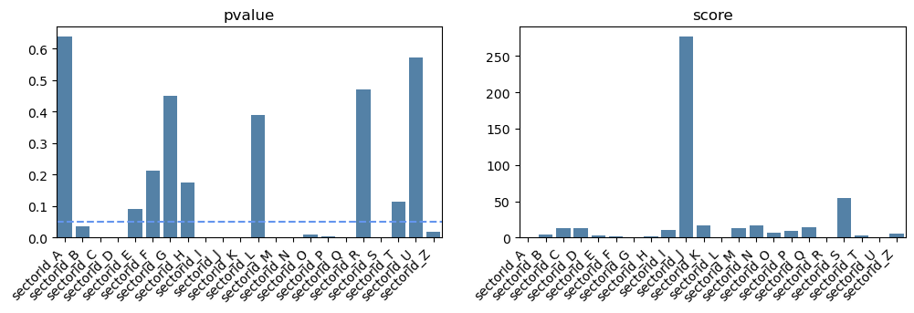

```python
columns = ['sectorId_A','sectorId_B', 'sectorId_C', 'sectorId_D', 'sectorId_E', 'sectorId_F',
           'sectorId_G', 'sectorId_H', 'sectorId_I', 'sectorId_J', 'sectorId_K', 'sectorId_L',
           'sectorId_M', 'sectorId_N', 'sectorId_O', 'sectorId_P', 'sectorId_Q', 'sectorId_R',
           'sectorId_S', 'sectorId_T', 'sectorId_U','sectorId_Z']
applyTest(consolidacion, columns, "IND_CLIENTE", chi2, 'all')
```

```python
consolidacion = consolidacion.drop(columns=["sectorId_A","sectorId_E","sectorId_F","sectorId_G","sectorId_H",
                                            "sectorId_L","sectorId_R","sectorId_T","sectorId_U"])
```

Se reescala el valor del PIB del departamento de la empresa más consultada por usuario.

```python
from sklearn.preprocessing import MinMaxScaler
scaler = MinMaxScaler()
consolidacion["PIB"] = scaler.fit_transform(consolidacion[["PIB"]])
```

Se acaban obteniendo 30 variables a utilizar en los modelos

```python
consolidacion.head(5)
```

|  | IND_CLIENTE | BONDAD_EMAIL_SIMP | numConsumos | numSesiones | diasParaUltimoConsumo | diasParaUltimaSesion | CANAL_REGISTRO_1 | CANAL_REGISTRO_2 | CANAL_REGISTRO_3 | CANAL_REGISTRO_6 | ... | sectorId_I | sectorId_J | sectorId_K | sectorId_M | sectorId_N | sectorId_O | sectorId_P | sectorId_Q | sectorId_S | sectorId_Z |
| --- | --- | --- | --- | --- | --- | --- | --- | --- | --- | --- | --- | --- | --- | --- | --- | --- | --- | --- | --- | --- | --- |
| 0 | 0 | 1.0 | 0.083333 | 0.130435 | 0.0 | 0.0 | 0.0 | 0.0 | 0.0 | 1.0 | ... | 0.0 | 0.0 | 0.0 | 0.0 | 0.0 | 0.0 | 0.0 | 0.0 | 0.0 | 0.0 |
| 1 | 0 | 1.0 | 0.083333 | 0.173913 | 0.0 | 0.0 | 0.0 | 0.0 | 1.0 | 0.0 | ... | 0.0 | 0.0 | 0.0 | 0.0 | 0.0 | 0.0 | 0.0 | 0.0 | 0.0 | 0.0 |
| 2 | 0 | 0.0 | 0.250000 | 0.217391 | 0.0 | 0.0 | 0.0 | 1.0 | 0.0 | 0.0 | ... | 0.0 | 0.0 | 0.0 | 0.0 | 0.0 | 0.0 | 0.0 | 0.0 | 0.0 | 0.0 |
| 3 | 0 | 1.0 | 0.083333 | 0.130435 | 0.0 | 0.0 | 0.0 | 0.0 | 1.0 | 0.0 | ... | 0.0 | 1.0 | 0.0 | 0.0 | 0.0 | 0.0 | 0.0 | 0.0 | 0.0 | 0.0 |
| 4 | 0 | 1.0 | 0.250000 | 0.260870 | 0.0 | 0.0 | 0.0 | 0.0 | 0.0 | 1.0 | ... | 0.0 | 0.0 | 0.0 | 1.0 | 0.0 | 0.0 | 0.0 | 0.0 | 0.0 | 0.0 |

5 rows × 30 columns

Se escribe el dataframe en un archivo:

```python
consolidacion.to_parquet("/Archivos/consolidacionSegundoCiclo.parquet")
```